# Assignment 08

Author

Benjamin Reese

### Packages

```r
## Loading in Packages
library(readr)
library(tidyverse)
library(tidymodels)
library(patchwork)
library(factoextra)
library(broom)
library(tidytext)
library(lubridate)
library(SnowballC)
library(igraph)
library(ggraph)
library(stringr)
library(stopwords)
library(textrecipes)
library(tidyclust)
```

## Exercise 01

### (a)

```r
## Loading in  votes data
votes_time_series <- read_csv("data/votes_time_series.csv")
## Loading in states region data
states_regions <- read_csv("data/states_regions.csv")

## Replacing NAs with 0s
votes_103 <- votes_time_series %>%
  mutate_all(funs(ifelse(is.na(.), 0, .))) %>%
  filter(session==103) %>%
  left_join(states_regions, by = c("state" = "State Code")) ## Joining to region for later use
```

### (b)

```r
## Creating the Recipe for PCA
votes_pca_rec <-
  recipe(~., data = votes_103) %>%
  step_pca(starts_with("v")) %>%
  prep()
```

### (c)

```r
## Checking the percent variance for pc1
tidy(votes_pca_rec, number=1, type = "variance") %>%
  filter(terms == "percent variance", component == 1)
```

```
# A tibble: 1 × 4
  terms            value component id
  <chr>            <dbl>     <int> <chr>
1 percent variance  38.8         1 pca_PjqIR
```

```r
## Checking the cumulative percent variance for first five components
tidy(votes_pca_rec, number=1, type = "variance") %>%
  filter(terms == "cumulative percent variance", component <= 5)
```

```
# A tibble: 5 × 4
  terms                       value component id
  <chr>                       <dbl>     <int> <chr>
1 cumulative percent variance  38.8         1 pca_PjqIR
2 cumulative percent variance  62.3         2 pca_PjqIR
3 cumulative percent variance  65.0         3 pca_PjqIR
4 cumulative percent variance  66.9         4 pca_PjqIR
5 cumulative percent variance  68.4         5 pca_PjqIR
```

The first principal component explains $\approx 38%$ of the variance. The first five principal components cumulatively explain $\approx 68%$ of the variance. Most of the variance is being explained in the first two principal components.

### (d)

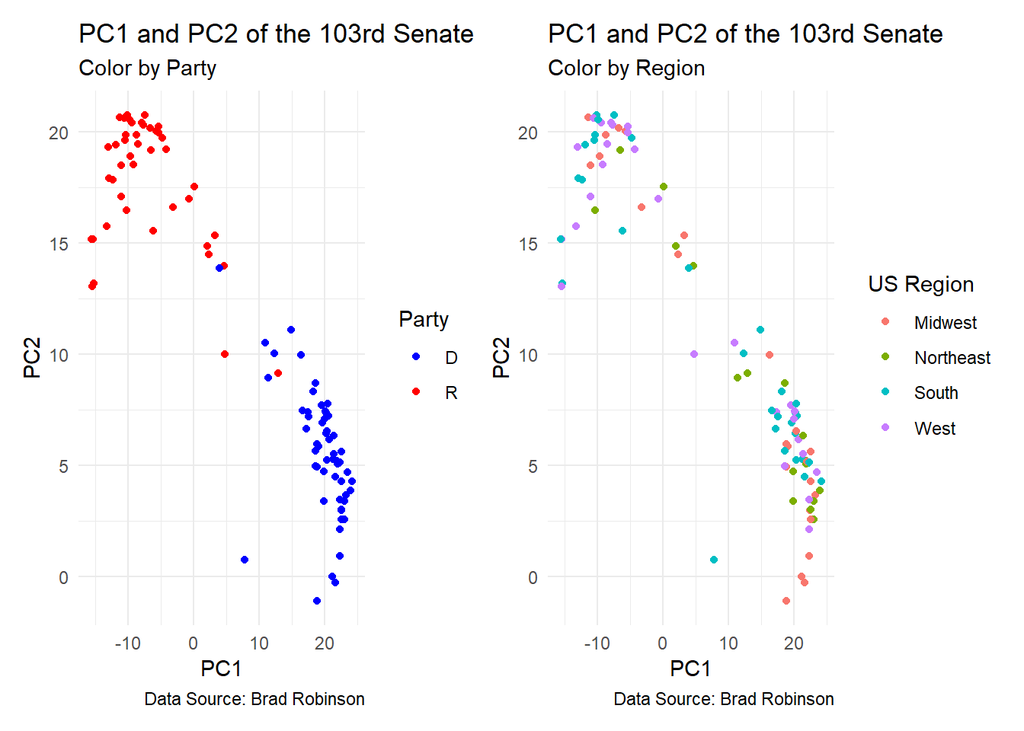

```r
## Party Plot
p1 <- votes_pca_rec %>%
  bake(new_data = votes_103) %>%
  ggplot(aes(x=PC1, y=PC2, color=party)) +
  geom_point() +
  scale_color_manual(values = c("D" = "blue", "R"= "red")) +
  theme_minimal() +
  labs(x="PC1", y= "PC2", title = "PC1 and PC2 of the 103rd Senate",
       subtitle = "Color by Party", color="Party",
       caption="Data Source: Brad Robinson")

## Region Plot
p2 <- votes_pca_rec %>%
  bake(new_data = NULL) %>%
  ggplot(aes(x=PC1, y=PC2, color=Region)) +
  geom_point() +
  theme_minimal() +
  labs(x="PC1", y= "PC2", title = "PC1 and PC2 of the 103rd Senate",
       subtitle = "Color by Region", color="US Region",
       caption="Data Source: Brad Robinson")

## Displaying Plots
p1 + p2
```

## Exercise 02

### (a)

```r
## Filtering votes_103 to only include votes
votes_numeric <- votes_103 %>%
  select(starts_with("v"))
```

### (b)

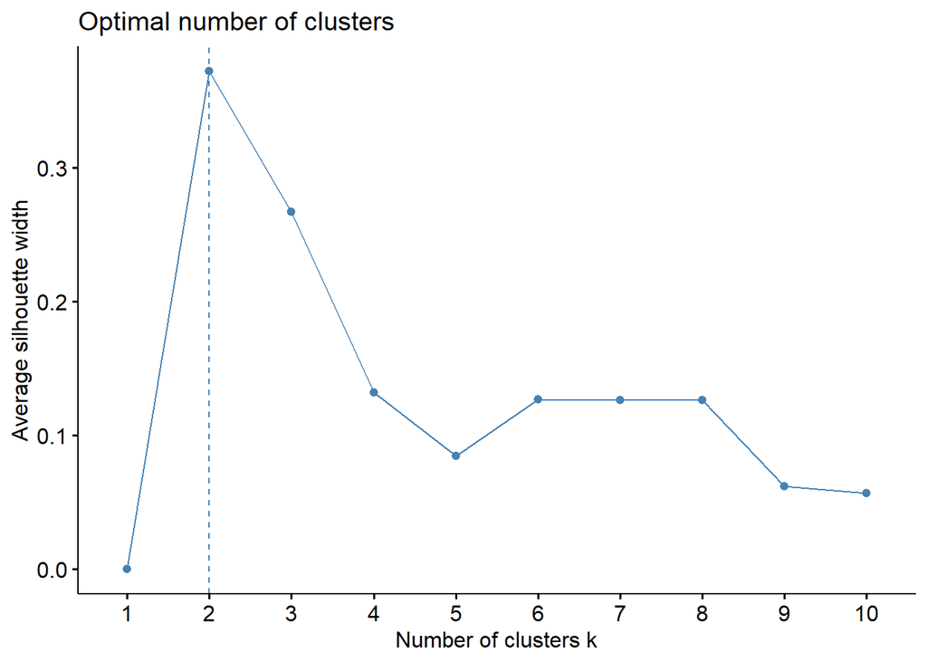

```r
## Setting Seed
set.seed(20220412)

## Creating recipe
kmeans_rec <- recipe(formula = ~ .,data = votes_numeric) %>%
  step_select(starts_with("v")) %>%
  prep()

votes_baked <- kmeans_rec %>%
  bake(new_data = votes_numeric)


## Silhouette Calculation
fviz_nbclust(votes_baked, FUN = kmeans, method = "silhouette")
```

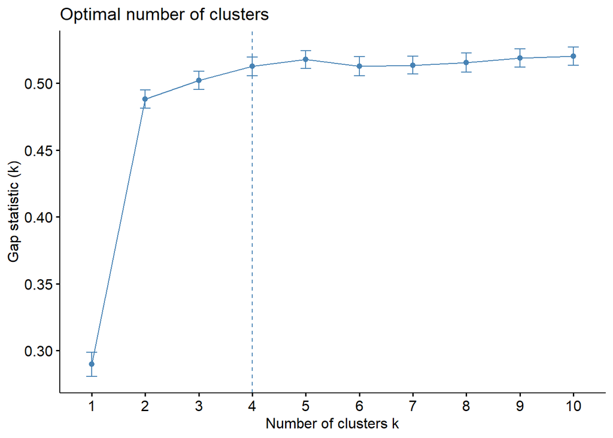

```r
## Gap Statistic Calculation
fviz_nbclust(votes_baked, FUN = kmeans, method = "gap_stat")
```

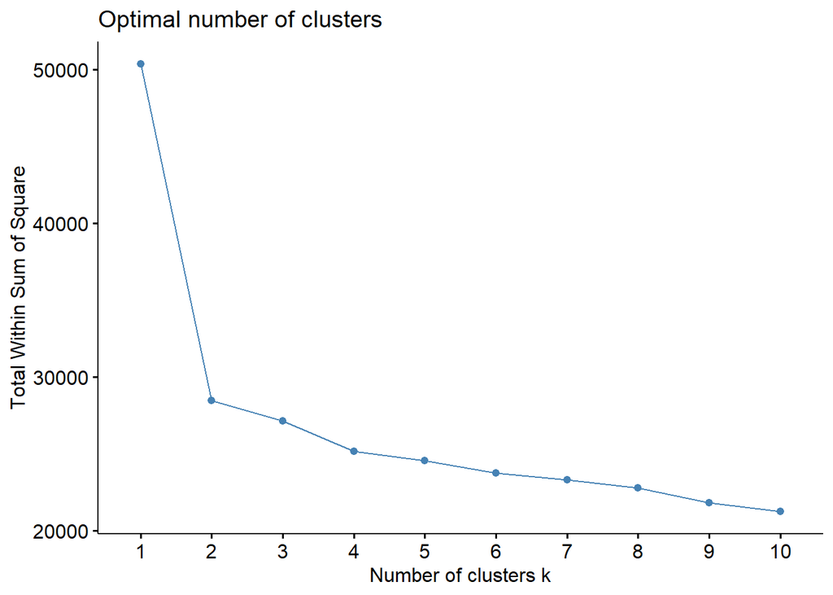

```r
## WSS Calculation
fviz_nbclust(votes_baked, FUN = kmeans, method = "wss")
```

### (c)

```r
## Creating the Function
#' k_clust
#'
#' @param k a numeric variable indicating the number of clusters to be used for k-means clustering
#' @param dataset a data frame to be input into the k-means cluster analysis model
#'
#' @return a ggplot object that plots the first and second principal components with color coded clusters
#'
#'
#' @examples k_clust(k=2, data=votes_103)
k_clust <- function(k, dataset) {
  ## Creating recipe
kmeans_rec <- recipe(formula = ~ .,data = dataset) %>%
  step_select(starts_with("v"))

rec_pca <- recipe(formula = ~ ., data = dataset) %>%
  step_select(starts_with("v")) %>%
  step_pca(all_numeric(), id = "pca")

## Creating model
k_means_spec <- k_means(num_clusters = k) %>%
  set_engine("stats", nstart = 100)

## Creating workflow
k_means_wflow <- workflow(
  preprocessor = rec_pca,
  spec = k_means_spec)

## Fitting Model
votes_k_means_fit <- k_means_wflow %>%
  fit(data = dataset)

## Creating Dataframe to visualize
votes_data <- bind_cols(
  select(dataset), votes_k_means_fit %>%
    extract_recipe() %>%
    bake(dataset),
  cluster = votes_k_means_fit %>%
    extract_cluster_assignment() %>%
    pull(.cluster)) %>%
    mutate(cluster = str_replace(cluster, "Cluster_",""))

## Plot
ggplot() +
  geom_point(
    data = votes_data,
    mapping = aes(PC1, PC2, color = factor(cluster)),
    alpha = 0.5) +
  labs(title = paste0("K-Means with K=", k, " and PCA"),
       x = "PC1",
       y = "PC2", color="Cluster",
       caption="Data Source: Brad Robinson") +
  theme_minimal() +
  guides(text = NULL)
}
```

### (d)

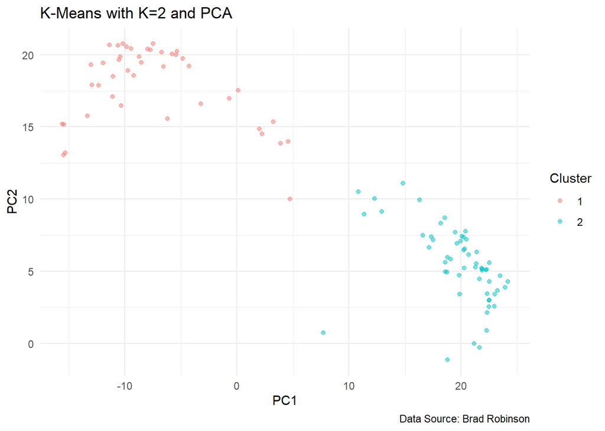

```r
## Running functions
## Silhouette
k_clust(k=2, data=votes_103)
```

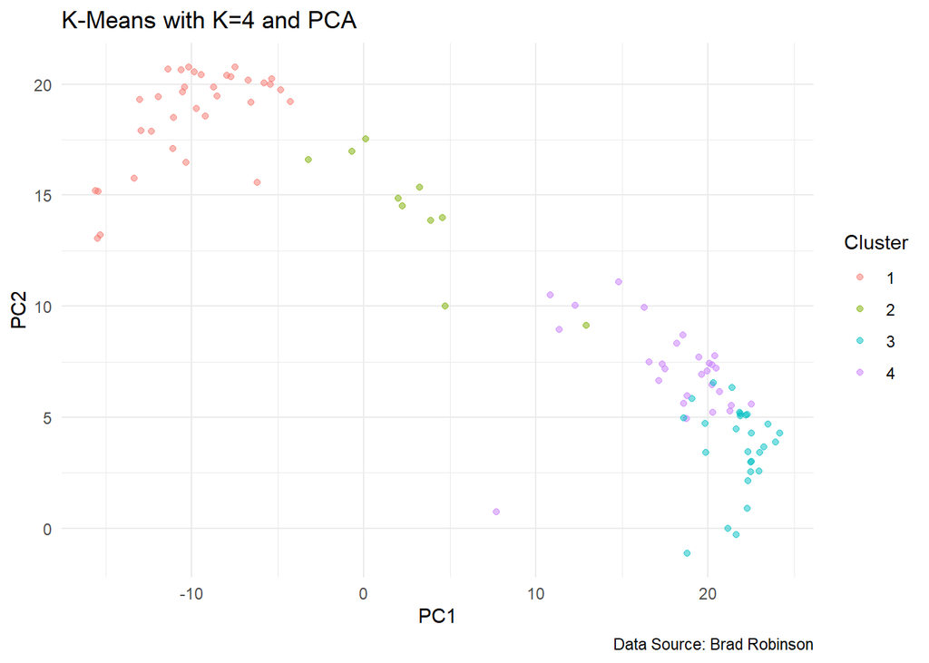

```r
## WSS
k_clust(k=4, data=votes_103)
```

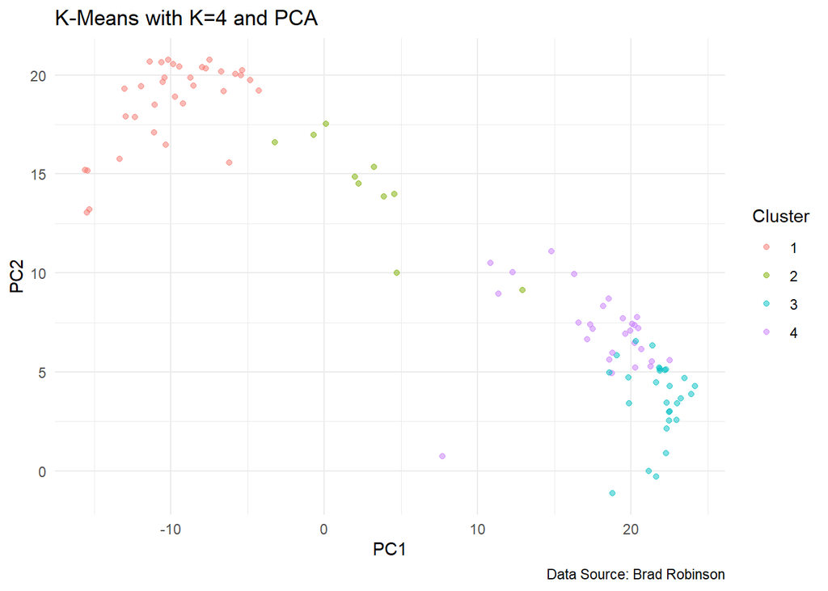

```r
## Gap Statistic
k_clust(k=4, data=votes_103)
```

## Exercise 03

### (a)

```r
## Loading executive orders data
executive_orders <- read_csv("data/executive-orders.csv")

## Filtering out text NAs
exec_orders <- executive_orders %>%
  filter(!is.na(text))

## Creating bigrams
tidy_exec <- exec_orders %>%
  unnest_tokens(bigram, text, token = "ngrams", n = 2)%>%
  filter(!is.na(bigram))
```

### (b)

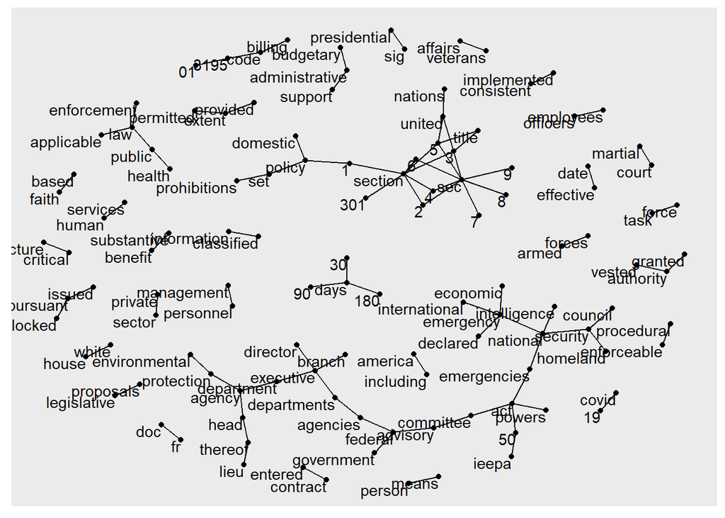

```r
## Separating, filtering, and counting bigrams
bigram_150 <- tidy_exec %>%
  separate(col = "bigram", into = c("word1", "word2")) %>%
  filter(!word1 %in% stop_words$word) %>%
  filter(!word2 %in% stop_words$word) %>%
  count(word1, word2, sort = TRUE) %>%
  filter(n>150)

# plot the bigrams that exist more than 150 times
bigram_graph <- bigram_150 %>%
  graph_from_data_frame()

# plot the relationships (you may want to make the plot window bigger)
set.seed(2017)
ggraph(bigram_graph, layout = "fr") +
  geom_edge_link() +
  geom_node_point() +
  geom_node_text(aes(label = name), vjust = 1, hjust = 1)
```

### (c)

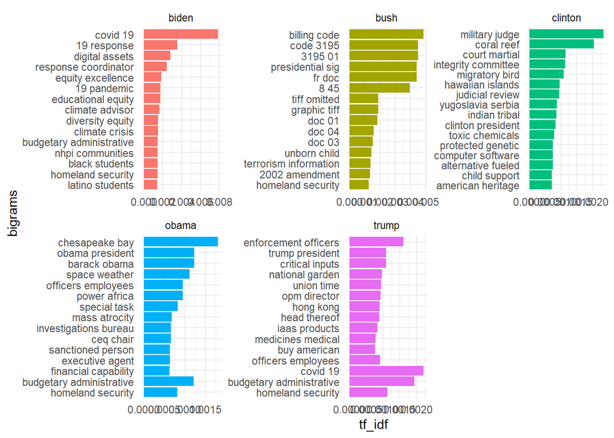

```r
## Calculating tf_idf for each bigram-president pair
tf_idf <- tidy_exec %>%
  separate(col = "bigram", into = c("word1", "word2")) %>%
  filter(!word1 %in% stop_words$word) %>%
  filter(!word2 %in% stop_words$word) %>%
  mutate(bigrams = paste(word1, word2)) %>%
  count(president, bigrams, sort = TRUE) %>%
  bind_tf_idf(term = bigrams, document = president, n = n)

## Plotting bigram-president pair
tf_idf %>%
  group_by(president) %>%
  top_n(15, tf_idf) %>%
  mutate(bigrams = reorder(bigrams, tf_idf)) %>%
  ggplot(aes(tf_idf, bigrams, fill = president)) +
  geom_col() +
  facet_wrap(~president, scales = "free") +
  theme_minimal() +
  guides(fill = "none")
```

## Exercise 04

### (a)

```r
## Importing Senate bills data
bills <- read_csv("data/senate_bills_114.csv") %>%
  mutate(passed = factor(passed, labels = c("1", "0"), levels = c("1", "0")))

## Counting How Many Bills Passed
bills %>%
  count(passed)
```

```
# A tibble: 2 × 2
  passed     n
  <fct>  <int>
1 1        108
2 0       3440
```

108 bills passed and 3440 bills failed.

### (b)

```r
## Seeting the Seed
set.seed(20220414)

## Splitting into training and testing
bills <- bills %>%
  select(-bill_number)

## Splitting the Sample
split <- initial_split(bills, prop = 0.75, strata = "passed")

## Training and Testing
bills_train <- training(split)
bills_test <- testing(split)
```

### (c)

```r
## Creating recipe
bills_rec <- recipe(passed~., data = bills_train) %>%
  step_tokenize(description) %>%
  step_stopwords(description) %>%
  step_stem(description) %>%
  step_tokenfilter(description) %>%
  step_tfidf(description)
```

### (d)

```r
## Prepping and Baking Recipe
bake(prep(bills_rec, training = bills_train), new_data = bills_train)
```

```
# A tibble: 2,661 × 101
   passed tfidf_descri…¹ tfidf…² tfidf…³ tfidf…⁴ tfidf…⁵ tfidf…⁶ tfidf…⁷ tfidf…⁸
   <fct>           <dbl>   <dbl>   <dbl>   <dbl>   <dbl>   <dbl>   <dbl>   <dbl>
 1 0              0.0221  0.0254 0.00713   0      0.0137  0       0.0301  0.0119
 2 0              0.0500  0.0505 0         0      0       0       0.0636  0
 3 0              0       0      0         0.585  0       0       0.244   0
 4 1              0       0      0         0      0       0       0       0
 5 0              0       0      0.0521    0      0       0       0.0586  0
 6 0              0.0411  0.0415 0         0      0       0       0.0784  0
 7 0              0       0      0         0      0       0       0.0396  0
 8 0              0       0      0         0      0       0       0.0813  0
 9 0              0.0460  0.0464 0         0      0       0       0.0293  0
10 0              0.0303  0.0305 0.0343    0      0       0.0547  0.0193  0
# … with 2,651 more rows, 92 more variables: tfidf_description_activ <dbl>,
#   tfidf_description_administr <dbl>, tfidf_description_agenc <dbl>,
#   tfidf_description_agreement <dbl>, tfidf_description_allow <dbl>,
#   tfidf_description_amend <dbl>, tfidf_description_amount <dbl>,
#   tfidf_description_applic <dbl>, tfidf_description_appropri <dbl>,
#   tfidf_description_area <dbl>, tfidf_description_assist <dbl>,
#   tfidf_description_author <dbl>, tfidf_description_avail <dbl>, …
```

```r
custom_stop_words <- c("1", "2", "3", "2015", "2016", "a", "an", "and",
                       "account", "act", "code", "doc")

## Re-creating recipe
bills_rec2 <- recipe(passed~., data = bills_train) %>%
  step_tokenize(description) %>%
  step_stopwords(description, custom_stopword_source = custom_stop_words) %>%
  step_stem(description) %>%
  step_tokenfilter(description) %>%
  step_tfidf(description)

## Prepping and Baking Recipe
bake(prep(bills_rec2, training = bills_train), new_data = bills_train)
```

```
# A tibble: 2,661 × 101
   passed tfidf_descri…¹ tfidf…² tfidf…³ tfidf…⁴ tfidf…⁵ tfidf…⁶ tfidf…⁷ tfidf…⁸
   <fct>           <dbl>   <dbl>   <dbl>   <dbl>   <dbl>   <dbl>   <dbl>   <dbl>
 1 0              0.0139  0.0183  0.0106 0.00260  0.0307 0.00426  0.0109 0.00279
 2 0              0       0       0      0        0      0.0191   0.0244 0
 3 0              0       0       0      0        0      0        0      0
 4 1              0       0       0      0        0      0        0      0
 5 0              0.0276  0       0.0421 0        0      0.0225   0.0287 0
 6 0              0.0203  0       0      0        0      0        0      0
 7 0              0.0155  0.0934  0      0        0      0.0127   0.0646 0
 8 0              0       0       0      0        0      0.0260   0.0331 0
 9 0              0       0.0243  0      0.0240   0      0.0263   0.117  0
10 0              0       0       0      0        0      0        0.0182 0
# … with 2,651 more rows, 92 more variables: tfidf_description_ar <dbl>,
#   tfidf_description_assist <dbl>, tfidf_description_at <dbl>,
#   tfidf_description_author <dbl>, tfidf_description_be <dbl>,
#   tfidf_description_bill <dbl>, tfidf_description_by <dbl>,
#   tfidf_description_care <dbl>, tfidf_description_certain <dbl>,
#   tfidf_description_commun <dbl>, tfidf_description_congress <dbl>,
#   tfidf_description_depart <dbl>, tfidf_description_design <dbl>, …
```

### (e)

```r
## Logistic Regression Model
lr_mod <-
  logistic_reg() %>%
  set_engine("glm") %>%
  set_mode(mode="classification")

## Logistic Regression Workflow
lr_wf <-
  workflow() %>%
  add_model(lr_mod) %>%
  add_recipe(bills_rec2)

## Fitting the Logistic Regression Model
lr_fit <-
  lr_wf%>%
  fit(data = bills_train)
```

### (f)

```r
## Selecting the Predictions
predictions <- bind_cols(
  bills_test,
  predict(object = lr_fit, new_data = bills_test),
  predict(object = lr_fit, new_data = bills_test, type = "prob")
)

## The Predictions
select(predictions, passed, starts_with(".pred"))
```

```
# A tibble: 887 × 4
   passed .pred_class  .pred_1 .pred_0
   <fct>  <fct>          <dbl>   <dbl>
 1 0      0           0.0168     0.983
 2 0      0           0.00329    0.997
 3 0      0           0.00327    0.997
 4 0      0           0.000864   0.999
 5 0      0           0.0301     0.970
 6 0      0           0.0495     0.950
 7 0      0           0.0168     0.983
 8 0      0           0.00906    0.991
 9 0      0           0.109      0.891
10 0      0           0.000385   1.00
# … with 877 more rows
```

```r
## Confusion matrix
conf_mat(data = predictions, truth = passed, estimate = .pred_class)
```

```
          Truth
Prediction   1   0
         1   1   8
         0  19 859
```

```r
## Accuracy
accuracy(data = predictions, truth = passed, estimate = .pred_class)
```

```
# A tibble: 1 × 3
  .metric  .estimator .estimate
  <chr>    <chr>          <dbl>
1 accuracy binary         0.970
```

```r
## Precision
precision(data = predictions, truth = passed, estimate = .pred_class)
```

```
# A tibble: 1 × 3
  .metric   .estimator .estimate
  <chr>     <chr>          <dbl>
1 precision binary         0.111
```

```r
## Recall/Sensitivity
recall(data = predictions, truth = passed, estimate = .pred_class)
```

```
# A tibble: 1 × 3
  .metric .estimator .estimate
  <chr>   <chr>          <dbl>
1 recall  binary          0.05
```

```r
## ROC Curve
roc_curve(data = predictions, truth = passed, estimate = .pred_1)
```

```
# A tibble: 854 × 3
    .threshold specificity sensitivity
         <dbl>       <dbl>       <dbl>
 1 -Inf             0                1
 2    2.22e-16      0                1
 3    1.14e-13      0.0104           1
 4    1.68e-12      0.0115           1
 5    2.58e-12      0.0127           1
 6    2.83e-12      0.0138           1
 7    4.04e-12      0.0150           1
 8    5.37e-12      0.0161           1
 9    6.72e-12      0.0173           1
10    7.58e-12      0.0185           1
# … with 844 more rows
```

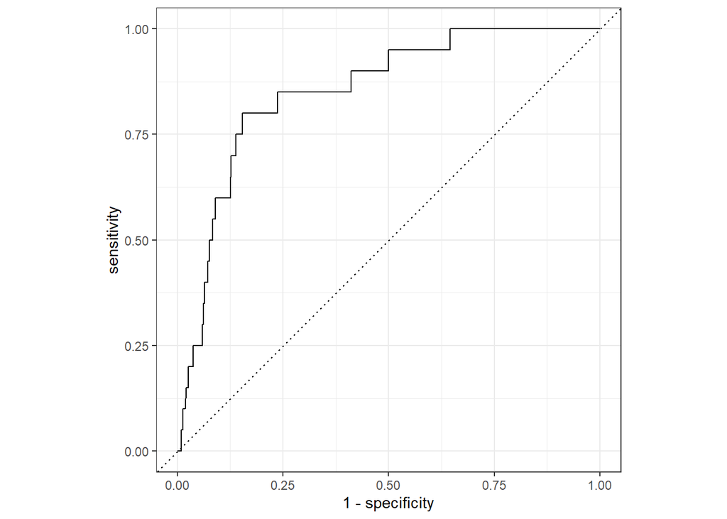

```r
## ROC Curve Plot
predictions %>%
  roc_curve(truth = passed, .pred_1) %>%
  autoplot()
```

```r
## AUC
roc_auc(data = predictions, truth = passed, estimate = .pred_1)
```

```
# A tibble: 1 × 3
  .metric .estimator .estimate
  <chr>   <chr>          <dbl>
1 roc_auc binary         0.852
```

The accuracy, or how often the model is correct, is quite high, about .97. A high accuracy, all else equal, is a sign of a high quality model. The precision and recall are not high, though. Recall, or how often the model is correct when there is an event is only about .05 and precision, or how often the model is correct when it predicts events is about .11. Both of these values are quite low. The ROC and AUC, however, are relatively good. The ROC Curve, as shown in the plot above, is consistent with a good classifier. Further, the AUC is about .85, which is also good, though not excellent. Overall, the model has high accuracy, but its usefulness is limited by its low recall and precision.

The first improvement that I can suggest is to include the actual text of each bill beyond their short descriptions. Having more text and, more specifically, a model that predicts bill passage based on the language in the actual bill provisions should increase the quality of the model. In addition, having more data, even without bill text, would be helpful. Having many different years of bills may improve model fit, though with changing partisan dynamics, a longer time frame may not be helpful.

Second, it would be an improvement to include other non-text variables in the model such as the party of the sponsor, the party in control of the chamber, the monetary cost of the bill, and other factors that may influence the probability of a bill passing.

Third, utilizing v-fold cross-validation could produce a “better” model that could then be implemented on the testing data. Through the process of cross-validation, perhaps a better model could be found. Further, utilizing alternate classification algorithms like a CART model or a random forest model could result in a higher quality predictive model. This, combined with cross-validation, should be tried to find the best candidate model.